# ST558_PROJECT2

Qiaozhi Bao 2020/10/6

# Introduction

## Describe the data

The Online News Popularity data set was published two years ago to summarize a heterogeneous set of features about articles published by Mashable in a period of two years. There are 61 variables in total from the data set above: 58 predictive attributes, 2 non-predictive and 1 goal field.More details and summarization will be discussed later in this project. ## The purpose of Analysis  
The purpose of this analysis is to create two models(ensemble and not ensemble) to generate the best predict of the response attribute–shares.Our analysis will help to determine what kind of content would be most popular. ## Methods For this project,I first split the data into training set and test set,then I examine the data with summary statistics and correlation plots to see the relationships between predictive attributes and the relationship between predictive attributes and response variables,then some meaningless variables were moved. I then utilized the caret package to create two models.Tree-based model chosen using leave one out cross validation.Boosted tree model chosen using cross-validation.

# Data Study

## Description of the Used Data

```r
# Load all libraries
library(tidyverse)
library(ggplot2)
library(randomForest)
library(caret)
library(tree)
library(gbm)
library(corrplot)
library(e1071)
set.seed(1)
```

```r
# Read in data and removing the first two columns as they are not predictive variables.
news_pop <- read_csv('./OnlineNewsPopularity.csv') %>% select(-`url`,-`timedelta`)
# First to see Monday data
Mon_data <- news_pop%>% filter(weekday_is_monday==1)
Mon_data <- Mon_data %>% select(!starts_with('weekday_is'))
# Check if we have missing values, answer is 'No'
sum(is.na(Mon_data))
```

```
## [1] 0
```

```r
Mon_data
```

As there is no missing value in our Monday data, we will step to split data. By using sample(), with 70% of the data goes to the training set (4,662 observations, Mon_train) and 30% goes to the test set (1,999 observations, Mon_test).

```r
# Split Monday data,70% for training set and 30% for test set
set.seed(1)
train <- sample(1:nrow(Mon_data),size = nrow(Mon_data)*0.7)
test <- dplyr::setdiff(1:nrow(Mon_data),train)
train_data <-Mon_data[train,]
test_data <- Mon_data[test,]
train_data
test_data
```

# Data Summarizations

## Response variable

First I plot the histogram of the response variable `shares` and found it is a right-skewed distribution variable,then I performed log-transformation on `shares` and plot histogram too.

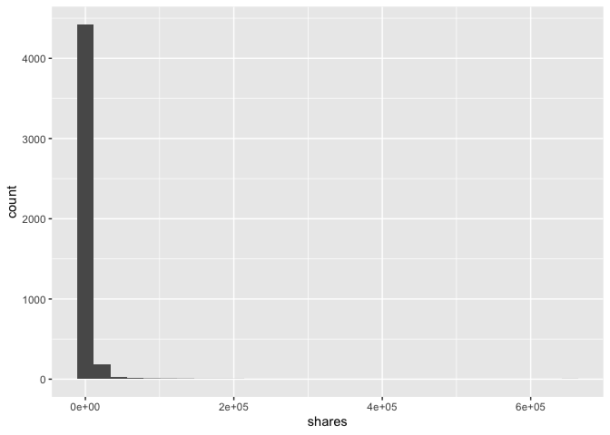

```r
# Histogram of the response variable
ggplot(data=train_data, aes(x=shares))+geom_histogram()
```

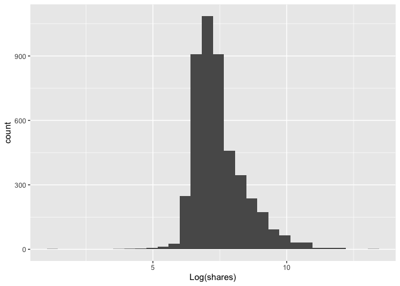

```r
train_data$shares <- log(train_data$shares)
ggplot(data=train_data, aes(x=shares))+geom_histogram()+ xlab('Log(shares)')
```

## Predictor Variables  
I used the summary() function to calculate summary statistics for each of the quantitative variables in Mon_data.

```r
summary(train_data)
```

```
##  n_tokens_title  n_tokens_content n_unique_tokens  n_non_stop_words
##  Min.   : 2.00   Min.   :   0.0   Min.   :0.0000   Min.   :0.0000
##  1st Qu.: 9.00   1st Qu.: 248.0   1st Qu.:0.4738   1st Qu.:1.0000
##  Median :10.00   Median : 397.5   Median :0.5427   Median :1.0000
##  Mean   :10.42   Mean   : 538.2   Mean   :0.5308   Mean   :0.9691
##  3rd Qu.:12.00   3rd Qu.: 711.0   3rd Qu.:0.6088   3rd Qu.:1.0000
##  Max.   :18.00   Max.   :7764.0   Max.   :1.0000   Max.   :1.0000
##  n_non_stop_unique_tokens   num_hrefs      num_self_hrefs      num_imgs
##  Min.   :0.0000           Min.   :  0.00   Min.   : 0.000   Min.   : 0.000
##  1st Qu.:0.6287           1st Qu.:  4.00   1st Qu.: 1.000   1st Qu.: 1.000
##  Median :0.6939           Median :  7.00   Median : 3.000   Median : 1.000
##  Mean   :0.6728           Mean   : 10.62   Mean   : 3.367   Mean   : 4.382
##  3rd Qu.:0.7544           3rd Qu.: 13.00   3rd Qu.: 4.000   3rd Qu.: 3.000
##  Max.   :1.0000           Max.   :162.00   Max.   :51.000   Max.   :93.000
##    num_videos     average_token_length  num_keywords    data_channel_is_lifestyle
##  Min.   : 0.000   Min.   :0.000        Min.   : 1.000   Min.   :0.00000
##  1st Qu.: 0.000   1st Qu.:4.475        1st Qu.: 6.000   1st Qu.:0.00000
##  Median : 0.000   Median :4.656        Median : 7.000   Median :0.00000
##  Mean   : 1.367   Mean   :4.536        Mean   : 7.153   Mean   :0.04719
##  3rd Qu.: 1.000   3rd Qu.:4.840        3rd Qu.: 9.000   3rd Qu.:0.00000
##  Max.   :74.000   Max.   :6.513        Max.   :10.000   Max.   :1.00000
##  data_channel_is_entertainment data_channel_is_bus data_channel_is_socmed
##  Min.   :0.0000                Min.   :0.0000      Min.   :0.00000
##  1st Qu.:0.0000                1st Qu.:0.0000      1st Qu.:0.00000
##  Median :0.0000                Median :0.0000      Median :0.00000
##  Mean   :0.2059                Mean   :0.1695      Mean   :0.05277
##  3rd Qu.:0.0000                3rd Qu.:0.0000      3rd Qu.:0.00000
##  Max.   :1.0000                Max.   :1.0000      Max.   :1.00000
##  data_channel_is_tech data_channel_is_world   kw_min_min       kw_max_min
##  Min.   :0.0000       Min.   :0.0000        Min.   : -1.00   Min.   :     0
##  1st Qu.:0.0000       1st Qu.:0.0000        1st Qu.: -1.00   1st Qu.:   441
##  Median :0.0000       Median :0.0000        Median : -1.00   Median :   651
##  Mean   :0.1836       Mean   :0.2072        Mean   : 26.82   Mean   :  1231
##  3rd Qu.:0.0000       3rd Qu.:0.0000        3rd Qu.:  4.00   3rd Qu.:  1000
##  Max.   :1.0000       Max.   :1.0000        Max.   :318.00   Max.   :298400
##    kw_avg_min        kw_min_max       kw_max_max       kw_avg_max       kw_min_avg
##  Min.   :   -1.0   Min.   :     0   Min.   :     0   Min.   :     0   Min.   :  -1.0
##  1st Qu.:  136.2   1st Qu.:     0   1st Qu.:843300   1st Qu.:173315   1st Qu.:   0.0
##  Median :  230.5   Median :  1400   Median :843300   Median :242336   Median : 994.2
##  Mean   :  317.1   Mean   : 11822   Mean   :748229   Mean   :257156   Mean   :1086.4
```

[output cut: 43 more lines]

```
##  Max.   :1.000         Max.   : 0.0000       Max.   : 0.0000
##  max_negative_polarity title_subjectivity title_sentiment_polarity
##  Min.   :-1.000        Min.   :0.0000     Min.   :-1.00000
##  1st Qu.:-0.125        1st Qu.:0.0000     1st Qu.: 0.00000
##  Median :-0.100        Median :0.1333     Median : 0.00000
##  Mean   :-0.106        Mean   :0.2771     Mean   : 0.06694
##  3rd Qu.:-0.050        3rd Qu.:0.5000     3rd Qu.: 0.13636
##  Max.   : 0.000        Max.   :1.0000     Max.   : 1.00000
##  abs_title_subjectivity abs_title_sentiment_polarity     shares
##  Min.   :0.0000         Min.   :0.000                Min.   : 1.386
##  1st Qu.:0.1500         1st Qu.:0.000                1st Qu.: 6.817
##  Median :0.5000         Median :0.000                Median : 7.244
##  Mean   :0.3391         Mean   :0.153                Mean   : 7.459
##  3rd Qu.:0.5000         3rd Qu.:0.250                3rd Qu.: 7.901
##  Max.   :0.5000         Max.   :1.000                Max.   :13.389
```

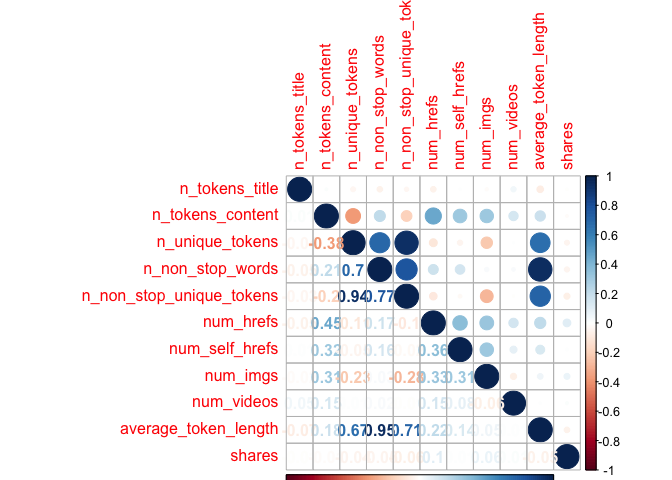

```r
correlation1 <- cor(train_data[,c(1:10,52)])
corrplot(correlation1,type='upper',tl.pos = 'lt')
corrplot(correlation1,type='lower',method = 'number',add = T,diag = F,tl.pos = 'n')
```

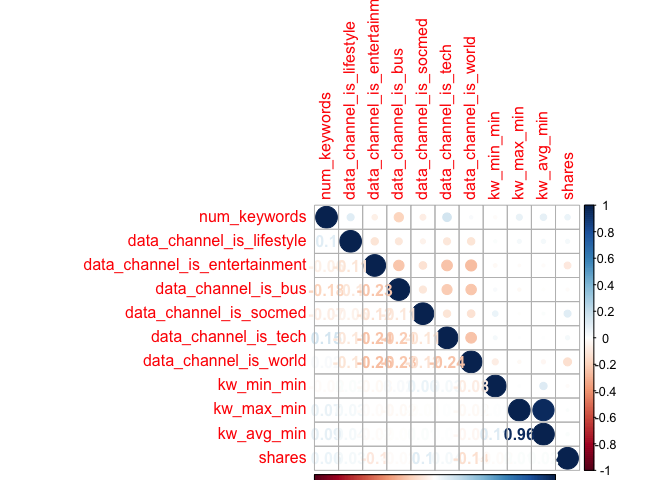

```r
correlation2 <- cor(train_data[,c(11:20,52)])
corrplot(correlation2,type='upper',tl.pos = 'lt')
corrplot(correlation2,type='lower',method = 'number',add = T,diag = F,tl.pos = 'n')
```

```r
correlation3 <- cor(train_data[,c(21:30,52)])
```

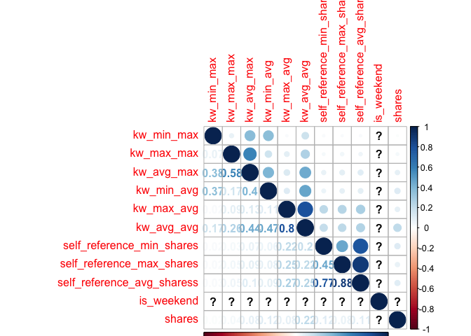

```r
corrplot(correlation3,type='upper',tl.pos = 'lt')
corrplot(correlation3,type='lower',method = 'number',add = T,diag = F,tl.pos = 'n')
```

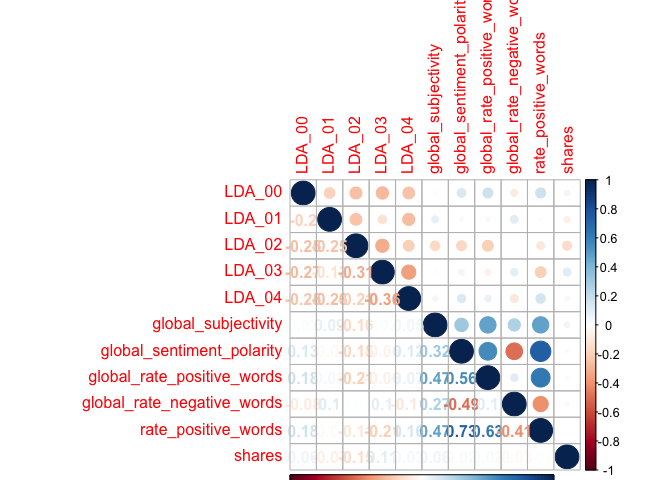

```r
correlation4 <- cor(train_data[,c(31:40,52)])
corrplot(correlation4,type='upper',tl.pos = 'lt')
corrplot(correlation4,type='lower',method = 'number',add = T,diag = F,tl.pos = 'n')
```

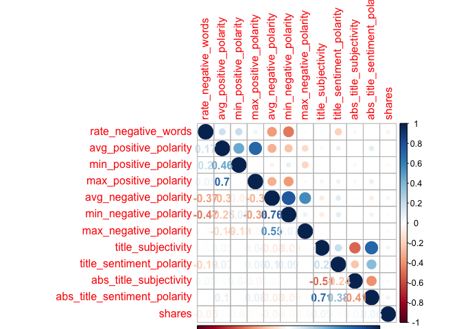

```r
correlation5 <- cor(train_data[,c(41:51,52)])
corrplot(correlation5,type='upper',tl.pos = 'lt')
corrplot(correlation5,type='lower',method = 'number',add = T,diag = F,tl.pos = 'n')
```

From the correlation plot,I decided to remove some meaningless variables:`kw_min_min`,`kw_avg_min`,`kw_min_avg`,`is_weekend` Also some highly correlated variables will be removed too,then we will get a new train set and test set

```r
train_data <- train_data %>% select(!starts_with("LDA"),-is_weekend)
test_data <- test_data %>% select(!starts_with("LDA"),-is_weekend)
train_data <- train_data %>% select(!starts_with('kw'))
test_data <- train_data %>% select(!starts_with('kw'))
```

```r
train_data
```

# First Model

## Tree based model chosen using leave one out cross validation

```r
tree.method <- train(shares ~.,data = train_data,method='rpart',
                       preProcess = c("center","scale"),
                     trControl = trainControl(method ='LOOCV'))
```

```r
tree.method$results
tree.method$bestTune
pred.tree <- predict(tree.method,test_data)
postResample(pred.tree,test_data$shares)
```

```
##       RMSE   Rsquared        MAE
## 0.93558824 0.06097103 0.69938961
```

# Second Model

## Boosted tree model chosen using cross-validation

```r
# We will fit the model using repeated CV
boosted.method <- train(shares ~.,data = train_data,method = 'gbm',
                      trControl = trainControl(method = 'repeatedcv', number=5,repeats =2),
                      preProcess = c("center","scale"),
                      verbose = FALSE)
```

```r
pred.boost <- predict(boosted.method,test_data)
boostRMSE <- sqrt(mean((pred.boost- test_data$shares)^2))
boostRMSE
```

```
## [1] 0.8810502
```